# US Econ Census Data

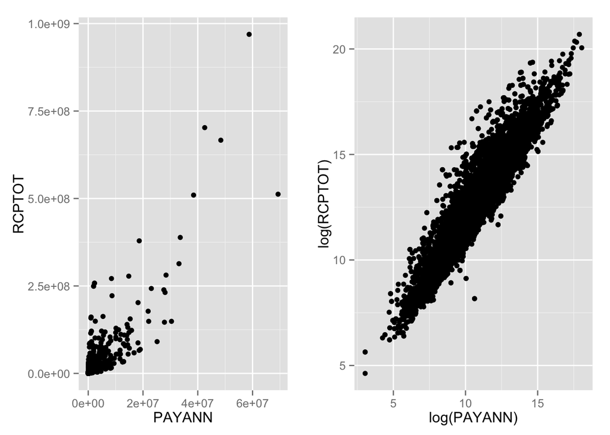

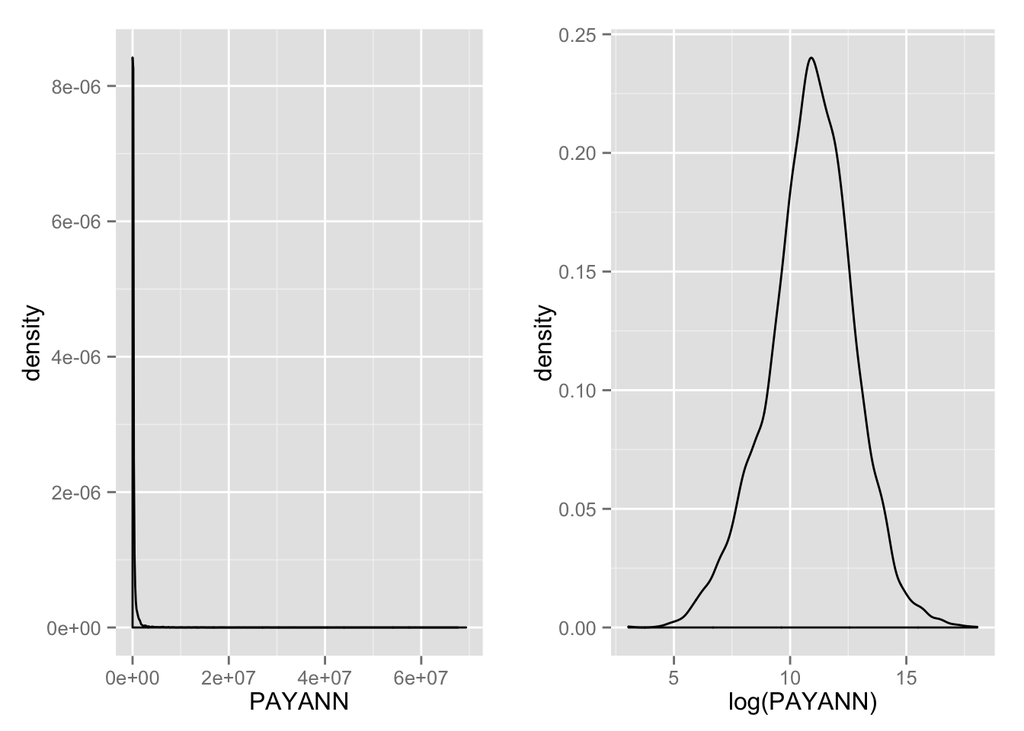

**Mean Function**  
The mean transformation, *mean(x)*, calculates the average of a vector of values. This is a useful way to compress and summarize many data entries into one meaningful value. In the example below, we used the U.S. Economic Census 2012 data to calculate the mean annual income per person in each state of the U.S. in 2012. This is a number that a viewer of our visualization can relate to.  
Below is a plot of mean values:

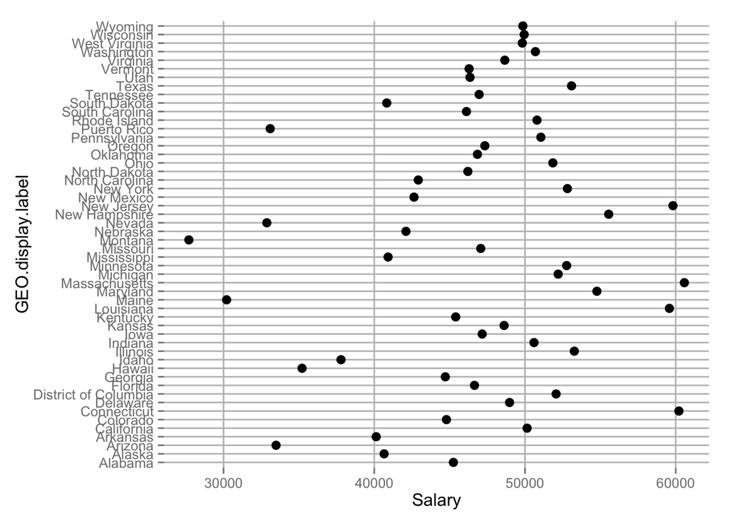

**Sort Transformation**  
The *sort(x)* function is used to rearrange the order of a vector of data entries. This helps us to better highlight and visualize trends. In our example, we use the sort function to arrange states in order of average annual income per person and we are able to better understand how the values for each state relate to one another. Rather than having an extremely messy plot that is difficult to read, let alone discover trends, the new sorted graphic allows for comprehensive examination.

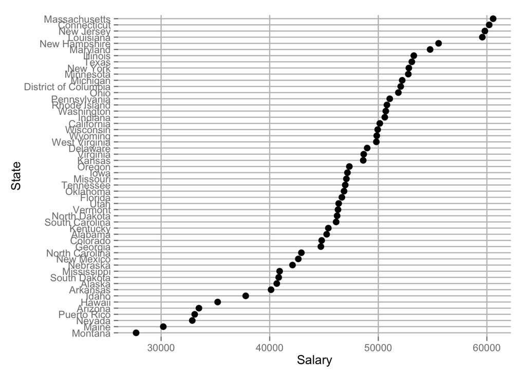

**Sum Transformation**  
The *sum(x)* function is used to add up the entries of a vector and output their total. This is often a useful step in summarizing data or aiding a further transformation. Using data from the U.S. Economic Census in 2002, 2007, and 2012, we calculate the total revenue of each state for each of the three years. The data was originally given as the revenue of each industry in each state; however, this would be unreadable when charted and generally unuseful when attempting to look for trends at the state level.

**Rank Transformation**  
The *rank(x)* function is used to assign a rank value to each data entry in a vector. This is very helpful for sorting and highlighting the relative relationships between data entries. Using this transformation, we can create a time-series that shows the change in rank of state revenues over a 10 year span.

**Group Transformation**  
The group transformation, *grpfun(x1,x2,…; f(x))*, is when the same function is applied to groups of elements. In this example, we have applied the rank function, as described above, grouped by each year of data. This creates a ranking of the states by revenue for each year in order to finalize the time-series.

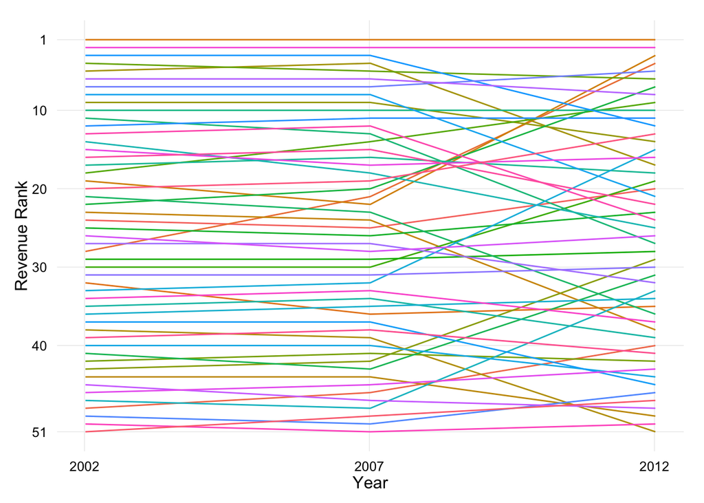